# Unfair Coins

2/20/2020

Initial question: A jar holds 1000 coins. Out of all of the coins, 999 are fair and one is double-sided with two heads. Picking a coin at random, you toss the coin ten times. Given that you see 10 heads, what is the probability that the coin is double headed and the probability that the next toss of the coin is also a head?

Lets take a look at this question and then play around with some of the given assumptions. First, lets breakdown the original:

```r
NumberOfFlips = 10
NumberOfFairCoins = 999
NumberOfUnfairCoins = 1
FairOdds = .5
UnfairOdds = 1

# Probability of a fair or unfair coin
ProbabilityFair = NumberOfFairCoins / (NumberOfFairCoins + NumberOfUnfairCoins) # 999/1000
ProbabilityUnfair = NumberOfUnfairCoins / (NumberOfFairCoins + NumberOfUnfairCoins) # 1/1000
```

Now, to figured out the 11th flip, lets ask what are the odds we have for the flip. That would be the probability its heads on a fair coin with the likelihood we have a fair coin plus the probability it heads with the likelihood we have an unfair coin. To find out the likelihood of which coin we have, we’ll use Bayes Theorem, or P(A|B) = P(B|A) * P(A) / P(B). In simplier terms, we will ask what is the likelihood we have the fair coin given 10 flips are heads P(Fair | 10 Heads) and the likelihood hood we have an unfair coin given 10 flips are heads P(Unfair | 10 Heads).

To start, lets ask what is the probability of a fair or unfair coin given 10 flips, all heads:

```r
#P(Fair|10H) = P(10H | Fair) * P(Fair) / P(10H)

Probability10HGivenFair = FairOdds^NumberOfFlips #P(10H | Fair)

Probability10H = FairOdds^NumberOfFlips * ProbabilityFair + UnfairOdds^NumberOfFlips * ProbabilityUnfair # P(10H)

ProbFairCoinGiven10Flips = Probability10HGivenFair * ProbabilityFair / Probability10H
ProbFairCoinGiven10Flips
```

```
## [1] 0.4938211
```

```r
#P(Unfair|10H) = P(10H | Unfair) * P(Unfair) / P(10H)

Probability10HGivenUnfair = UnfairOdds^NumberOfFlips #P(10H | Unfair)

Probability10H = FairOdds^NumberOfFlips * ProbabilityFair + UnfairOdds^NumberOfFlips * ProbabilityUnfair # P(10H)

ProbUnFairCoinGiven10Flips = Probability10HGivenUnfair * ProbabilityUnfair / Probability10H
ProbUnFairCoinGiven10Flips
```

```
## [1] 0.5061789
```

Quick check that the two probabilities add up to 1.

```r
1 == ProbUnFairCoinGiven10Flips+ProbFairCoinGiven10Flips
```

```
## [1] TRUE
```

Odds we have a fair coin is 49.38211% and the odds we have the unfair coin is 50.61789%.

Therefore, odds the next flip will be heads would be the odds it heads given a fair coin (.5 * .4938) + odds if its unfair (1 * .5062) or:

```r
FairOdds * ProbFairCoinGiven10Flips + UnfairOdds * ProbUnFairCoinGiven10Flips
```

```
## [1] 0.7530895
```

Now, lets take a look at what would happen if we had more or less flips before estimating what the next flip would be.

We’ll take the above work, but we’ll make a data table for tracking results, and use a loop to run through flips. And then plot the probability that the nth next flip with be heads.

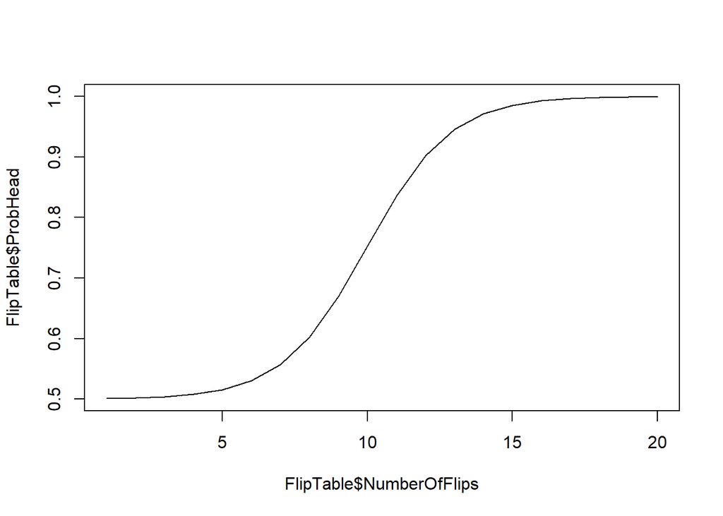

```r
FlipTable = data.table::data.table(NumberOfFlips = 1:20, ProbHead = 1)
for (i in 1:20){
  #Set up variable for table
  NumberOfFlips = i

  # Fit above work into a single formula
  FlipTable$ProbHead[i] = FairOdds *  (FairOdds^NumberOfFlips*ProbabilityFair/
      (FairOdds^NumberOfFlips * ProbabilityFair + UnfairOdds^NumberOfFlips * ProbabilityUnfair)) +
    UnfairOdds * (UnfairOdds^NumberOfFlips*ProbabilityUnfair /
      (FairOdds^NumberOfFlips * ProbabilityFair + UnfairOdds^NumberOfFlips * ProbabilityUnfair))
}

plot(x = FlipTable$NumberOfFlips, y=FlipTable$ProbHead, type = "l")
```

We can see that around the 15th flip, its pretty much guaranteed that the next flip will be heads and you almost certainly have the unfair coin.

So lets also see what happens if we change the number of unfair coins, what is the the probability of the 11th flip being heads if we add more unfair coins.

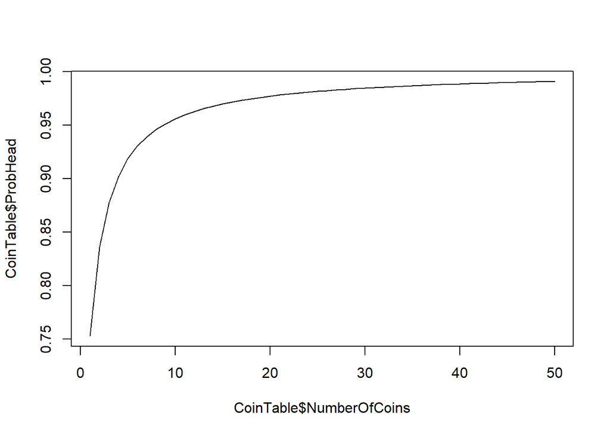

```r
CoinTable = data.table::data.table(NumberOfCoins = 1:50, ProbHead = 1)
for (i in 1:50){
  #Set up variable for table and reset number of flips
  NumberOfFairCoins = 1000-i
  NumberOfUnfairCoins = i
  NumberOfFlips = 10
  ProbabilityFair = NumberOfFairCoins / (NumberOfFairCoins + NumberOfUnfairCoins) # (1000-i)/1000
  ProbabilityUnfair = NumberOfUnfairCoins / (NumberOfFairCoins + NumberOfUnfairCoins) # i/1000

  #Combine above work into a single formula
  CoinTable$ProbHead[i] = FairOdds *  (FairOdds^NumberOfFlips*ProbabilityFair/
      (FairOdds^NumberOfFlips * ProbabilityFair + UnfairOdds^NumberOfFlips * ProbabilityUnfair)) +
    UnfairOdds * (UnfairOdds^NumberOfFlips*ProbabilityUnfair /
      (FairOdds^NumberOfFlips * ProbabilityFair + UnfairOdds^NumberOfFlips * ProbabilityUnfair))
}

plot(x = CoinTable$NumberOfCoins, y=CoinTable$ProbHead, type = "l")
```

By adding more coins, we have an explosive increase that is over 95% by the 9th unfair coin.